# Capstone_project_Final_version

## **2. ResNet50 (with multiple layers)**

```python
from  tensorflow.keras.applications import resnet50
```

### Creating the model

```python
resnet50 = resnet50
conv_model = resnet50.ResNet50(weights='imagenet', include_top=False, input_shape=(224,224,3))
x = Flatten()(conv_model.layers[-1].output)
x = Dense(512, activation='relu')(x)
x = Dense(224, activation='relu')(x)
x = Dense(224, activation='relu')(x)
x = Dense(224, activation='relu')(x)
x = Dense(224, activation='relu')(x)
x = Dense(224, activation='sigmoid')(x)
x = Dense(224, activation='sigmoid')(x)
predictions = Dense(197, activation='softmax')(x)

full_model = Model(inputs=conv_model.input, outputs=predictions)
```

```
Downloading data from https://storage.googleapis.com/tensorflow/keras-applications/resnet/resnet50_weights_tf_dim_ordering_tf_kernels_notop.h5
```

### Summary of model

```python
full_model.summary()
```

```
Model: "model_1"
__________________________________________________________________________________________________
Layer (type)                    Output Shape         Param #     Connected to
==================================================================================================
input_3 (InputLayer)            [(None, 224, 224, 3) 0
__________________________________________________________________________________________________
conv1_pad (ZeroPadding2D)       (None, 230, 230, 3)  0           input_3[0][0]
__________________________________________________________________________________________________
conv1_conv (Conv2D)             (None, 112, 112, 64) 9472        conv1_pad[0][0]
__________________________________________________________________________________________________
conv1_bn (BatchNormalization)   (None, 112, 112, 64) 256         conv1_conv[0][0]
__________________________________________________________________________________________________
conv1_relu (Activation)         (None, 112, 112, 64) 0           conv1_bn[0][0]
__________________________________________________________________________________________________
pool1_pad (ZeroPadding2D)       (None, 114, 114, 64) 0           conv1_relu[0][0]
__________________________________________________________________________________________________
pool1_pool (MaxPooling2D)       (None, 56, 56, 64)   0           pool1_pad[0][0]
__________________________________________________________________________________________________
conv2_block1_1_conv (Conv2D)    (None, 56, 56, 64)   4160        pool1_pool[0][0]
__________________________________________________________________________________________________
conv2_block1_1_bn (BatchNormali (None, 56, 56, 64)   256         conv2_block1_1_conv[0][0]
__________________________________________________________________________________________________
conv2_block1_1_relu (Activation (None, 56, 56, 64)   0           conv2_block1_1_bn[0][0]
__________________________________________________________________________________________________
conv2_block1_2_conv (Conv2D)    (None, 56, 56, 64)   36928       conv2_block1_1_relu[0][0]
__________________________________________________________________________________________________
conv2_block1_2_bn (BatchNormali (None, 56, 56, 64)   256         conv2_block1_2_conv[0][0]
__________________________________________________________________________________________________
conv2_block1_2_relu (Activation (None, 56, 56, 64)   0           conv2_block1_2_bn[0][0]
__________________________________________________________________________________________________
conv2_block1_0_conv (Conv2D)    (None, 56, 56, 256)  16640       pool1_pool[0][0]
__________________________________________________________________________________________________
conv2_block1_3_conv (Conv2D)    (None, 56, 56, 256)  16640       conv2_block1_2_relu[0][0]
__________________________________________________________________________________________________
conv2_block1_0_bn (BatchNormali (None, 56, 56, 256)  1024        conv2_block1_0_conv[0][0]
__________________________________________________________________________________________________
conv2_block1_3_bn (BatchNormali (None, 56, 56, 256)  1024        conv2_block1_3_conv[0][0]
__________________________________________________________________________________________________
conv2_block1_add (Add)          (None, 56, 56, 256)  0           conv2_block1_0_bn[0][0]
                                                                 conv2_block1_3_bn[0][0]
```

[output cut: 337 more lines]

```
__________________________________________________________________________________________________
dense_21 (Dense)                (None, 224)          50400       dense_20[0][0]
__________________________________________________________________________________________________
dense_22 (Dense)                (None, 224)          50400       dense_21[0][0]
__________________________________________________________________________________________________
dense_23 (Dense)                (None, 224)          50400       dense_22[0][0]
__________________________________________________________________________________________________
dense_24 (Dense)                (None, 224)          50400       dense_23[0][0]
__________________________________________________________________________________________________
dense_25 (Dense)                (None, 197)          44325       dense_24[0][0]
==================================================================================================
Total params: 75,379,685
Trainable params: 75,326,565
Non-trainable params: 53,120
__________________________________________________________________________________________________
```

### Define optimizer

```python
opt= Adam(learning_rate=0.001)
```

### Training [Forward pass and Backpropagation]

```python
#Compile
full_model.compile(optimizer= opt, loss = 'categorical_crossentropy', metrics = ['accuracy'])
```

```python
#Early stopping
early = EarlyStopping(monitor='val_accuracy',min_delta=0,patience=40,verbose=1,mode='auto')
```

```python
res_classifier=full_model.fit_generator(train_generator,steps_per_epoch = 2, epochs =30, validation_data = validation_generator,
		        validation_steps = 1,callbacks = [early])
```

### Plot Accuracy and Loss for Training and Validation

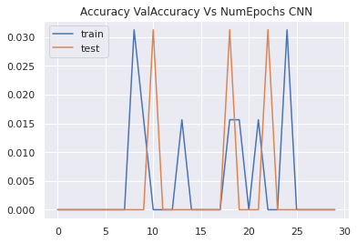

```
<function matplotlib.pyplot.show>
```

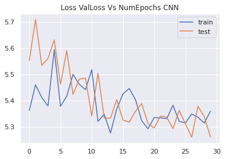

```python
train_loss = res_classifier.history['loss']
val_loss   = res_classifier.history['val_loss']

xc = res_classifier.epoch
plt.title("Accuracy ValAccuracy Vs NumEpochs CNN")
plt.plot(xc,res_classifier.history['accuracy'], label='train')
plt.plot(xc,res_classifier.history['val_accuracy'], label='test')
plt.legend()
plt.show()

plt.figure()
plt.title("Loss ValLoss Vs NumEpochs CNN")
plt.plot(xc, train_loss,label='train')
plt.plot(xc, val_loss,label='test')
plt.legend()
plt.show
```

### Evaluation

```python
train_acc = full_model.evaluate_generator(train_generator,steps = int(train_generator.samples/BATCH_SIZE))
val_acc = full_model.evaluate_generator(validation_generator, steps = int(validation_generator.samples/BATCH_SIZE))
```

```python
print(train_acc[1])
print(val_acc[1])
```

```
0.005290354136377573
0.005229083821177483
```

```python
#Adding Performance metrics of ResNet50 to the list
tempResultsDf = pd.DataFrame({'Model':['ResNet50'],  'Train_Accuracy': train_acc[1],'Test_Accuracy': val_acc[1]})
resultsDf = pd.concat([resultsDf, tempResultsDf])
resultsDf = resultsDf[['Model', 'Train_Accuracy','Test_Accuracy']]
resultsDf
```

|  | Model | Train_Accuracy | Test_Accuracy |
| --- | --- | --- | --- |
| 0 | CNN | 0.359129 | 0.158616 |
| 0 | ResNet50 | 0.005290 | 0.005229 |

## **3. VGG16**

```python
from tensorflow.keras.applications.vgg16 import VGG16
from tensorflow.keras.models import Model
```

### Creating the model

```python
print ( 'VGG with custom FC Layers')
vgg_conv = VGG16(weights='imagenet', include_top=False, input_shape= (224,224,3))
# Freeze all the layers except for the last layer:
for layer in vgg_conv.layers:
    layer.trainable = False

x = Flatten()(vgg_conv.output)
x = Dense(197, activation='softmax')(x)
vgg_model = Model(vgg_conv.input, x)
```

```
VGG with custom FC Layers
```

### Summary of model

```python
vgg_model.summary()
```

```
Model: "model_3"
_________________________________________________________________
Layer (type)                 Output Shape              Param #
=================================================================
input_5 (InputLayer)         [(None, 224, 224, 3)]     0
_________________________________________________________________
block1_conv1 (Conv2D)        (None, 224, 224, 64)      1792
_________________________________________________________________
block1_conv2 (Conv2D)        (None, 224, 224, 64)      36928
_________________________________________________________________
block1_pool (MaxPooling2D)   (None, 112, 112, 64)      0
_________________________________________________________________
block2_conv1 (Conv2D)        (None, 112, 112, 128)     73856
_________________________________________________________________
block2_conv2 (Conv2D)        (None, 112, 112, 128)     147584
_________________________________________________________________
block2_pool (MaxPooling2D)   (None, 56, 56, 128)       0
_________________________________________________________________
block3_conv1 (Conv2D)        (None, 56, 56, 256)       295168
_________________________________________________________________
block3_conv2 (Conv2D)        (None, 56, 56, 256)       590080
_________________________________________________________________
block3_conv3 (Conv2D)        (None, 56, 56, 256)       590080
_________________________________________________________________
block3_pool (MaxPooling2D)   (None, 28, 28, 256)       0
_________________________________________________________________
block4_conv1 (Conv2D)        (None, 28, 28, 512)       1180160
_________________________________________________________________
block4_conv2 (Conv2D)        (None, 28, 28, 512)       2359808
_________________________________________________________________
block4_conv3 (Conv2D)        (None, 28, 28, 512)       2359808
_________________________________________________________________
block4_pool (MaxPooling2D)   (None, 14, 14, 512)       0
_________________________________________________________________
block5_conv1 (Conv2D)        (None, 14, 14, 512)       2359808
_________________________________________________________________
block5_conv2 (Conv2D)        (None, 14, 14, 512)       2359808
_________________________________________________________________
block5_conv3 (Conv2D)        (None, 14, 14, 512)       2359808
_________________________________________________________________
block5_pool (MaxPooling2D)   (None, 7, 7, 512)         0
_________________________________________________________________
flatten_7 (Flatten)          (None, 25088)             0
_________________________________________________________________
dense_27 (Dense)             (None, 197)               4942533
=================================================================
Total params: 19,657,221
Trainable params: 4,942,533
Non-trainable params: 14,714,688
_________________________________________________________________
```

### Training [Forward pass and Backpropagation]

```python
#Compile the model with Adam optimizer
vgg_model.compile(optimizer = Adam(learning_rate=0.001), loss = 'categorical_crossentropy', metrics = ['accuracy'])
```

```python
early = EarlyStopping(monitor='val_accuracy',min_delta=0.01,patience=20,verbose=1,mode='auto')

#Training
vgg_classifier = vgg_model.fit_generator(train_generator, epochs =30, validation_data = validation_generator, callbacks = [early]  )
```

### Plot Accuracy and Loss for Training and Validation

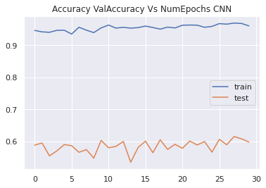

```
<function matplotlib.pyplot.show>
```

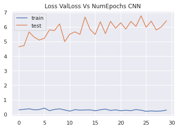

```python
train_loss = vgg_classifier.history['loss']
val_loss   = vgg_classifier.history['val_loss']

xc = vgg_classifier.epoch
plt.title("Accuracy ValAccuracy Vs NumEpochs CNN")
plt.plot(xc,vgg_classifier.history['accuracy'], label='train')
plt.plot(xc,vgg_classifier.history['val_accuracy'], label='test')
plt.legend()
plt.show()

plt.figure()
plt.title("Loss ValLoss Vs NumEpochs CNN")
plt.plot(xc, train_loss,label='train')
plt.plot(xc, val_loss,label='test')
plt.legend()
plt.show
```

```python
#vgg_model = keras.models.load_model('vgg.h5')
#vgg_model.load_weights('vgg_weights.h5')
```

### Save the model and weights

```python
vgg_model.save('./vgg.h5')

vgg_model.save_weights('./vgg_weights.h5')
```

### Evaluation

```python
train_acc = vgg_model.evaluate_generator(train_generator,steps = int(train_generator.samples/BATCH_SIZE))
val_acc = vgg_model.evaluate_generator(validation_generator, steps = int(validation_generator.samples/BATCH_SIZE))
```

```python
print(train_acc[1])
print(val_acc[1])
```

```
0.9386072754859924
0.5639940500259399
```

```python
#Adding Performance metrics of ResNet50 to the list
tempResultsDf = pd.DataFrame({'Model':['VGG16'],  'Train_Accuracy': train_acc[1],'Test_Accuracy': val_acc[1]})
resultsDf = pd.concat([resultsDf, tempResultsDf])
resultsDf = resultsDf[['Model', 'Train_Accuracy','Test_Accuracy']]
resultsDf
```

|  | Model | Train_Accuracy | Test_Accuracy |
| --- | --- | --- | --- |
| 0 | CNN | 0.359129 | 0.158616 |
| 0 | ResNet50 | 0.005290 | 0.005229 |
| 0 | VGG16 | 0.938607 | 0.563994 |

## **4. ResNet50 (without multiple layers)**

```python
from tensorflow.keras.applications.resnet50 import ResNet50
```

### Creating the model

```python
print ( 'ResNet with custom FC Layers')
resnet_conv = ResNet50(weights='imagenet', include_top=False, input_shape=(224,224,3))

# Freeze all the layers except for the last layer:
for layer in resnet_conv.layers:
    layer.trainable = False


x2 = Flatten()(resnet_conv.output)
x2 = Dense(197, activation='sigmoid')(x2)
resnet = Model(resnet_conv.input, x2)
```

```
ResNet with custom FC Layers
```

### Summary of model

```python
resnet.summary()
```

```
Model: "model_4"
__________________________________________________________________________________________________
Layer (type)                    Output Shape         Param #     Connected to
==================================================================================================
input_5 (InputLayer)            [(None, 224, 224, 3) 0
__________________________________________________________________________________________________
conv1_pad (ZeroPadding2D)       (None, 230, 230, 3)  0           input_5[0][0]
__________________________________________________________________________________________________
conv1_conv (Conv2D)             (None, 112, 112, 64) 9472        conv1_pad[0][0]
__________________________________________________________________________________________________
conv1_bn (BatchNormalization)   (None, 112, 112, 64) 256         conv1_conv[0][0]
__________________________________________________________________________________________________
conv1_relu (Activation)         (None, 112, 112, 64) 0           conv1_bn[0][0]
__________________________________________________________________________________________________
pool1_pad (ZeroPadding2D)       (None, 114, 114, 64) 0           conv1_relu[0][0]
__________________________________________________________________________________________________
pool1_pool (MaxPooling2D)       (None, 56, 56, 64)   0           pool1_pad[0][0]
__________________________________________________________________________________________________
conv2_block1_1_conv (Conv2D)    (None, 56, 56, 64)   4160        pool1_pool[0][0]
__________________________________________________________________________________________________
conv2_block1_1_bn (BatchNormali (None, 56, 56, 64)   256         conv2_block1_1_conv[0][0]
__________________________________________________________________________________________________
conv2_block1_1_relu (Activation (None, 56, 56, 64)   0           conv2_block1_1_bn[0][0]
__________________________________________________________________________________________________
conv2_block1_2_conv (Conv2D)    (None, 56, 56, 64)   36928       conv2_block1_1_relu[0][0]
__________________________________________________________________________________________________
conv2_block1_2_bn (BatchNormali (None, 56, 56, 64)   256         conv2_block1_2_conv[0][0]
__________________________________________________________________________________________________
conv2_block1_2_relu (Activation (None, 56, 56, 64)   0           conv2_block1_2_bn[0][0]
__________________________________________________________________________________________________
conv2_block1_0_conv (Conv2D)    (None, 56, 56, 256)  16640       pool1_pool[0][0]
__________________________________________________________________________________________________
conv2_block1_3_conv (Conv2D)    (None, 56, 56, 256)  16640       conv2_block1_2_relu[0][0]
__________________________________________________________________________________________________
conv2_block1_0_bn (BatchNormali (None, 56, 56, 256)  1024        conv2_block1_0_conv[0][0]
__________________________________________________________________________________________________
conv2_block1_3_bn (BatchNormali (None, 56, 56, 256)  1024        conv2_block1_3_conv[0][0]
__________________________________________________________________________________________________
conv2_block1_add (Add)          (None, 56, 56, 256)  0           conv2_block1_0_bn[0][0]
                                                                 conv2_block1_3_bn[0][0]
```

[output cut: 323 more lines]

```
conv5_block3_3_bn (BatchNormali (None, 7, 7, 2048)   8192        conv5_block3_3_conv[0][0]
__________________________________________________________________________________________________
conv5_block3_add (Add)          (None, 7, 7, 2048)   0           conv5_block2_out[0][0]
                                                                 conv5_block3_3_bn[0][0]
__________________________________________________________________________________________________
conv5_block3_out (Activation)   (None, 7, 7, 2048)   0           conv5_block3_add[0][0]
__________________________________________________________________________________________________
flatten_5 (Flatten)             (None, 100352)       0           conv5_block3_out[0][0]
__________________________________________________________________________________________________
dense_14 (Dense)                (None, 197)          19769541    flatten_5[0][0]
==================================================================================================
Total params: 43,357,253
Trainable params: 19,769,541
Non-trainable params: 23,587,712
__________________________________________________________________________________________________
```

### Training [Forward pass and Backpropagation]

```python
#Compile with optimizer
resnet.compile(optimizer = Adam(learning_rate=0.001), loss = 'categorical_crossentropy', metrics = ['accuracy'])

early = EarlyStopping(monitor='val_accuracy',min_delta=0.01,patience=2,verbose=1,mode='auto')

#Training
resnet_classifier = resnet.fit_generator(train_generator,epochs =30, validation_data = validation_generator, callbacks = [early]  )
```

```
Epoch 00004: early stopping
```

### Plot Accuracy and Loss for Training and Validation

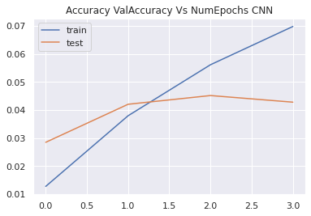

```
<function matplotlib.pyplot.show>
```

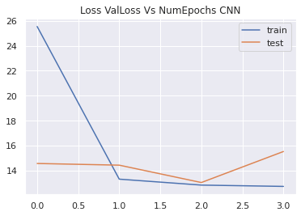

```python
train_loss = resnet_classifier.history['loss']
val_loss   = resnet_classifier.history['val_loss']

xc = resnet_classifier.epoch
plt.title("Accuracy ValAccuracy Vs NumEpochs CNN")
plt.plot(xc,resnet_classifier.history['accuracy'], label='train')
plt.plot(xc,resnet_classifier.history['val_accuracy'], label='test')
plt.legend()
plt.show()

plt.figure()
plt.title("Loss ValLoss Vs NumEpochs CNN")
plt.plot(xc, train_loss,label='train')
plt.plot(xc, val_loss,label='test')
plt.legend()
plt.show
```

### Evaluation

```python
train_acc = resnet.evaluate_generator(train_generator,steps = int(train_generator.samples/BATCH_SIZE))
val_acc = resnet.evaluate_generator(validation_generator, steps = int(validation_generator.samples/BATCH_SIZE))
```

```python
print(train_acc[1])
print(val_acc[1])
```

```
0.07221949100494385
0.04282868653535843
```

```python
#Adding Performance metrics of Custom ResNet50 to the list
tempResultsDf = pd.DataFrame({'Model':['ResNet Custom FC'],  'Train_Accuracy': train_acc[1],'Test_Accuracy': val_acc[1]})
resultsDf = pd.concat([resultsDf, tempResultsDf])
resultsDf = resultsDf[['Model', 'Train_Accuracy','Test_Accuracy']]
resultsDf
```

|  | Model | Train_Accuracy | Test_Accuracy |
| --- | --- | --- | --- |
| 0 | CNN | 0.359129 | 0.158616 |
| 0 | ResNet50 | 0.005290 | 0.005229 |
| 0 | VGG16 | 0.938607 | 0.563994 |
| 0 | ResNet Custom FC | 0.072219 | 0.042829 |

### Save model and weights

```python
resnet.save('./resnet.h5')

resnet.save_weights('./resnet_weights.h5')
```

## **5. InceptionResNetV2**

```python
import tensorflow as tf
from tensorflow.keras.applications import InceptionResNetV2
```

### Creating the model

```python
base_model = InceptionResNetV2(include_top=False, input_shape = INPUT_SIZE)
```

```
Downloading data from https://storage.googleapis.com/tensorflow/keras-applications/inception_resnet_v2/inception_resnet_v2_weights_tf_dim_ordering_tf_kernels_notop.h5
```

```python
classification_model = tf.keras.Sequential([
    base_model,
    tf.keras.layers.GlobalAveragePooling2D(),
    tf.keras.layers.Dense(128, activation='relu'),
    tf.keras.layers.BatchNormalization(),
    tf.keras.layers.Dropout(0.20),
    tf.keras.layers.Dense(197, activation='softmax')
])
```

### Summary of model

```python
classification_model.summary()
```

```
Model: "sequential_1"
_________________________________________________________________
Layer (type)                 Output Shape              Param #
=================================================================
inception_resnet_v2 (Functio (None, 5, 5, 1536)        54336736
_________________________________________________________________
global_average_pooling2d_1 ( (None, 1536)              0
_________________________________________________________________
dense_2 (Dense)              (None, 128)               196736
_________________________________________________________________
batch_normalization_204 (Bat (None, 128)               512
_________________________________________________________________
dropout_1 (Dropout)          (None, 128)               0
_________________________________________________________________
dense_3 (Dense)              (None, 197)               25413
=================================================================
Total params: 54,559,397
Trainable params: 54,498,597
Non-trainable params: 60,800
_________________________________________________________________
```

### Define optimizer

```python
lr=0.001
classification_model.compile(loss='categorical_crossentropy', optimizer=Adam(lr=lr), metrics=['accuracy'])
```

### Early Stopping and Save best model

```python
patience = 1
stop_patience = 3
factor = 0.5

callbacks = [
    tf.keras.callbacks.ModelCheckpoint("classify_model.h5", save_best_only=True, verbose = 0),
    tf.keras.callbacks.EarlyStopping(patience=stop_patience, monitor='val_accuracy', verbose=1),
    tf.keras.callbacks.ReduceLROnPlateau(monitor='val_accuracy', factor=factor, patience=patience, verbose=1)
]
```

### Training [Forward pass and Backpropagation]

```python
epochs = 20
history = classification_model.fit(train_generator, validation_data=validation_generator, epochs=epochs, callbacks=callbacks, verbose=1)
```

```
Epoch 00004: ReduceLROnPlateau reducing learning rate to 0.0005000000237487257.

Epoch 00007: ReduceLROnPlateau reducing learning rate to 0.0002500000118743628.

Epoch 00010: ReduceLROnPlateau reducing learning rate to 0.0001250000059371814.

Epoch 00014: ReduceLROnPlateau reducing learning rate to 6.25000029685907e-05.

Epoch 00018: ReduceLROnPlateau reducing learning rate to 3.125000148429535e-05.

Epoch 00020: ReduceLROnPlateau reducing learning rate to 1.5625000742147677e-05.
```

### Plot Accuracy and Loss for Training and Validation

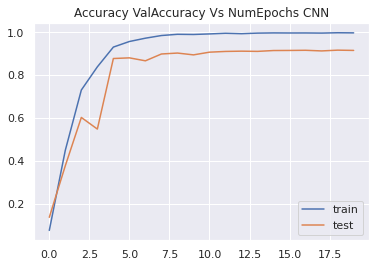

```
<function matplotlib.pyplot.show>
```

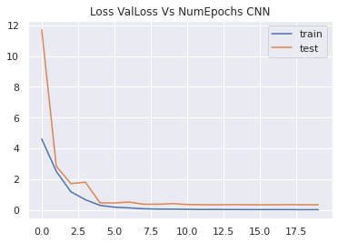

```python
train_loss = history.history['loss']
val_loss   = history.history['val_loss']

xc = history.epoch
plt.title("Accuracy ValAccuracy Vs NumEpochs CNN")
plt.plot(xc,history.history['accuracy'], label='train')
plt.plot(xc,history.history['val_accuracy'], label='test')
plt.legend()
plt.show()

plt.figure()
plt.title("Loss ValLoss Vs NumEpochs CNN")
plt.plot(xc, train_loss,label='train')
plt.plot(xc, val_loss,label='test')
plt.legend()
plt.show
```

### Evaluation

```python
train_acc = classification_model.evaluate_generator(train_generator,steps = int(train_generator.samples/BATCH_SIZE))
val_acc = classification_model.evaluate_generator(validation_generator, steps = int(validation_generator.samples/BATCH_SIZE))
```

```python
print(train_acc[1])
print(val_acc[1])
```

```
0.9981545209884644
0.9153386354446411
```

```python
#Adding Performance metrics of InceptionResNetv2 to the list
tempResultsDf = pd.DataFrame({'Model':['InceptionResNetv2'],  'Train_Accuracy': train_acc[1],'Test_Accuracy': val_acc[1]})
resultsDf = pd.concat([resultsDf, tempResultsDf])
resultsDf = resultsDf[['Model', 'Train_Accuracy','Test_Accuracy']]
resultsDf
```

[output not shown]

```python
import keras
```

```python
classification_model = keras.models.load_model('classify_model.h5')
```

### ****9. Compare the models****

```python
resultsDf
```

[output not shown]

**As seen from the table above, we tried different models for this classification problem.**

*InceptionResNetv2* gives the best accuracy. Therefore, it is our final selected model.

```python
final_model = classification_model
```

## Pickle model for future use

```python
final_model.save('./final_model.h5')
```

### ****10. Predictions****

```python
import keras
```

```python
final_model = keras.models.load_model('final_model.h5')
```

```python
from google.colab import files

uploaded = files.upload()
```

Upload widget is only available when the cell has been executed in the current browser session. Please rerun this cell to enable.

```
Saving test4.jpg to test4.jpg
```

**First Prediction**

[figure not shown]

```python
path = 'test1.jpg'
img = cv2.imread( path )
plt.grid(False)
plt.imshow(img)
```

```python
type(img)
```

```
numpy.ndarray
```

```python
from tensorflow.keras.utils import img_to_array, load_img
import cv2
```

```python
img = cv2.resize(img, (224,224),)
```

```python
img.shape
```

```
(224, 224, 3)
```

```python
pixels = img.astype('float32')
pixels /= 255.0
print(pixels.shape)
```

```
(224, 224, 3)
```

```python
#Expanding the dimensions of the numpy array to match the dimension expected by predict method
pixels = np.expand_dims(pixels, axis=0)
print(pixels.shape)
```

```
(1, 224, 224, 3)
```

```python
prediction = final_model.predict(pixels)
prediction = np.argmax(prediction, axis = 1)
```

```python
print(prediction)
```

```
[135]
```

```python
predicted_label = car_names[car_names['Class'] == prediction[0]]
```

```python
print(predicted_label)
```

```
                       CarLabel  Class
134  Hyundai Elantra Sedan 2007    135
```

**Second prediction**

[figure not shown]

```python
path = 'test4.jpg'
img = cv2.imread( path )
plt.grid(False)
plt.imshow(img)
```

```python
type(img)
```

```
numpy.ndarray
```

```python
from tensorflow.keras.utils import img_to_array, load_img
import cv2
```

```python
img = cv2.resize(img, (224,224),)
```

```python
img.shape
```

```
(224, 224, 3)
```

```python
pixels = img.astype('float32')
pixels /= 255.0
print(pixels.shape)
```

```
(224, 224, 3)
```

```python
#Expanding the dimensions of the numpy array to match the dimension expected by predict method
pixels = np.expand_dims(pixels, axis=0)
print(pixels.shape)
```

```
(1, 224, 224, 3)
```

```python
prediction = final_model.predict(pixels)
prediction = np.argmax(prediction, axis = 1)
```

```python
print(prediction)
```

```
[196]
```

```python
predicted_label = car_names[car_names['Class'] == prediction[0]]
```

```python
print(predicted_label)
```

```
                          CarLabel  Class
195  smart fortwo Convertible 2012    196
```

### ****11. GUI Creation****

- Design a clickable UI which can automate tasks performed under milestone 1
- Design a clickable UI which can automate tasks performed under milestone 2
- Design a clickable UI based interface which can allow the user to browse & input the image, output the class and the bounding box or mask [ highlight area of interest ] of the input image

#### *Functions to automate tasks for milestone 1*

1. Import the data
2. Map training and testing images to its classes.
3. Map training and testing images to its annotations.

Output: Images mapped to its class and annotation ready to be used for deep learning

```python
from tensorflow import keras

from imageai.Detection import ObjectDetection
import os
```

```python
import tkinter as tk
from tkinter import ttk
from tkinter import Button
from tkinter import filedialog
from PIL import ImageTk, Image
win = tk.Tk()
win.title("Car Classification")

# Set the resolution of window
win.geometry('550x300')

# Allow Window to be resizable
win.resizable(width = True, height = True)
```

**Functions to automate tasks for milestone 1**

1. Import the data
2. Map training and testing images to its classes.
3. Map training and testing images to its annotations.

**Output**: Images mapped to its class and annotation ready to be used for deep learning

**Function and UI control to Import data**

```python
def import_data():
    global car_names, train_data, test_date

    #Different car labels
    car_names = pd.read_csv( 'Car names and make.csv', header=None, names = ['CarLabel'] )

    #Train data
    train_data = pd.read_csv( 'Annotations/Train Annotations.csv', skiprows=1, names = ['ImageName', 'X1', 'Y1', 'X2' , 'Y2', 'Class'] )

    #Test data
    test_data = pd.read_csv( 'Annotations/Test Annotation.csv' , skiprows=1, names = ['ImageName', 'X1', 'Y1', 'X2' , 'Y2', 'Class'])

    #Replace '/' with '-' in the name
    car_names.loc[173,'CarLabel'] = 'Ram C-V Cargo Van Minivan 2012'


    Data=ttk.Label(win,text="Data Successfully Imported")
    Data.grid(row=0,column=1,sticky=tk.W)
```

```python
# Import Data Button

databutton = Button(win, text="Import Data", command=import_data, fg='blue')
databutton.grid(row=0,column=0)
```

**Function and UI control to map training and test images to classes and annotations**

```python
def map_images():

    global car_train_df, car_test_df

    #Map training images to corresponding classes and annotations
    car_names['Class'] = car_names.index + 1
    car_train_df = pd.merge(train_data, car_names, how = 'left', left_on='Class', right_on='Class' )

    #Map training images to corresponding classes and annotations
    car_test_df = pd.merge(test_data, car_names, how = 'left', left_on='Class', right_on='Class' )


    Data=ttk.Label(win,text="Training and Test images mapped to classes and annotations")
    Data.grid(row=1,column=1,sticky=tk.W)
```

```python
# Map Data Button

databutton = Button(win, text="Map Training and Test Data", command=map_images, fg='blue')
databutton.grid(row=1,column=0)
```

#### *Functions to automate tasks for milestone 2*

1. Design, train and test model to classify the car.
2. Pickle model to be used for future prediction

Output: Pickled model to be used for future prediction

**Function to design and train classifier; and add required UI controls**

```python
def TrainClassifier():
    global classification_model

    base_model = InceptionResNetV2(include_top=False, input_shape = INPUT_SIZE)

    classification_model = tf.keras.Sequential([
        base_model,
        tf.keras.layers.GlobalAveragePooling2D(),
        tf.keras.layers.Dense(128, activation='relu'),
        tf.keras.layers.BatchNormalization(),
        tf.keras.layers.Dropout(0.20),
        tf.keras.layers.Dense(197, activation='softmax')
    ])

    #Define optimizer
    lr=0.001
    classification_model.compile(loss='categorical_crossentropy', optimizer=Adam(lr=lr), metrics=['accuracy'])

    #Early Stopping and Save best model
    patience = 1
    stop_patience = 3
    factor = 0.5

    callbacks = [
        tf.keras.callbacks.ModelCheckpoint("classify_model.h5", save_best_only=True, verbose = 0),
        tf.keras.callbacks.EarlyStopping(patience=stop_patience, monitor='val_accuracy', verbose=1),
        tf.keras.callbacks.ReduceLROnPlateau(monitor='val_accuracy', factor=factor, patience=patience, verbose=1)
    ]

    #Training [Forward pass and Backpropagation]
    epochs = 20
    history = classification_model.fit(train_generator, validation_data=validation_generator, epochs=epochs, callbacks=callbacks, verbose=1)


    Data=ttk.Label(win,text="Classifier designed and trained")
    Data.grid(row=3,column=1,sticky=tk.W)
```

```python
# Train Classifier Button

databutton = Button(win, text="Design and Train Model", command=TrainClassifier, justify='right',fg='blue')
databutton.grid(row=3,column=0)
```

**Function and UI to pickle model**

```python
def pickle_model():

    #Pickle model for future use

    final_model = classification_model
    final_model.save('./final_model.h5')

    Data=ttk.Label(win,text="Model Pickled")
    Data.grid(row=4,column=1,sticky=tk.W)
```

```python
# Pickle Model Button

databutton = Button(win, text="Pickle Model", command=pickle_model, justify='right',fg='blue')
databutton.grid(row=4,column=0)
```

#### **Design a clickable UI based interface which can allow the user to browse & input the image, output the class and the bounding box of the input image**

Install imageai library

```python
!pip install imageai --upgrade
```

```python
from imageai.Detection import ObjectDetection
import os
```

```python
import shutil
```

**We will be using pre-trained yolo model for object detection**

```python
shutil.move("/content/drive/MyDrive/Colab Notebooks/CarImages/Trafficvideo/yolo.h5", "/content/drive/MyDrive/Colab Notebooks/Capstone/yolo.h5")
```

```
'/content/drive/MyDrive/Colab Notebooks/Capstone/yolo.h5'
```

**Define function to open dialog box to select image**

```python
def openfilename():

    # open file dialog box to select image
    filename = filedialog.askopenfilename(title ='Car')
    return filename
```

**Function to load image and display on UI**

```python
def load_img():

    global img,x,img1
    # Select the Imagename  from a folder
    x = openfilename()

    # opens the image
    img = Image.open(x)

    # resize the image and apply a high-quality down sampling filter
    img = img.resize((250, 250), Image.ANTIALIAS)

    img1 = img

    # PhotoImage class is used to add image to widgets, icons etc
    img = ImageTk.PhotoImage(img)

    # create a label
    Data=ttk.Label(win, image = img)

    # set the image as img
    Data.grid(row = 7, column = 0)
    Data.image = img
```

```python
# Upload Image Button

databutton = Button(win, text="Upload Image", command=load_img, justify='right',fg='blue')
databutton.grid(row=5,column=0)
```

**Function to detect car in image, draw bounding box around it and display on UI**

```python
def detect_object():
    from imageai.Detection import ObjectDetection
    import os

    current_directory = os.getcwd()

    detector = ObjectDetection()
    detector.setModelTypeAsYOLOv3()

    detector.setModelPath(os.path.join(current_directory , "yolo.h5"))
    detector.loadModel()

    detections = detector.detectObjectsFromImage(input_image=x,output_image_path=os.path.join(current_directory , "annoted.jpg"),minimum_percentage_probability=60)
    image_a = "annoted.jpg"


        # opens the image
    img = Image.open(image_a)

    # resize the image and apply a high-quality down sampling filter
    img = img.resize((250, 250), Image.ANTIALIAS)

    # PhotoImage class is used to add image to widgets, icons etc
    img = ImageTk.PhotoImage(img)

    # create a label
    Data=ttk.Label(win, image = img)

    # set the image as img
    Data.grid(row = 7, column=1)
    Data.image = img


    for eachObject in detections:
        Data=ttk.Label(win,text='IOU:')
        Data.grid(row=7,column=2,sticky=tk.W)
        Data=ttk.Label(win,text=eachObject["percentage_probability"]/100)
        Data.grid(row=7,column=3,sticky=tk.W)
```

```python
#Annotate image Button
databutton = Button(win, text="Annotate Image", command=detect_object, justify='right',fg='blue')
databutton.grid(row=8,column=0)
```

**Function to predict class**

```python
#function to predict class of image
def predict_class():

    path = /content/drive/MyDrive/Colab Notebooks/Capstone/annoted.jpg'

    image = cv2.imread(path)

    image = cv2.resize(image, (224,224),)
    pixels = image.astype('float32')
    pixels /= 255.0
    pixels = np.expand_dims(pixels, axis=0)
    prediction = final_model.predict(pixels)

    #Convert encoding to integer
    pred_int = np.argmax(prediction, axis=1)
    label = car_names[car_names['Class'] == pred_int[0]]


    Data=ttk.Label(win,text=label)
    Data.grid(row=9,column=1,sticky=tk.W)
```

```python
#Predict class Button
databutton = Button(win, text="Predict Class", command=predict_class, justify='right',fg='blue')
databutton.grid(row=9,column=0)
```

```python
win.mainloop()
```